# Homework 10

TJ Schaeffer

4/27/20

### Setup

```r
# clean up workspace environment
rm(list = ls())

# all packages used for the assignment
library(MASS)
library(car)
library(nortest)
library(dplyr)
library(ggplot2)
library(readr)
library(MuMIn)
library(corrplot)
library(lmtest)
library(StepReg)
# reading in data
pirates <- read.csv("462pirates.csv")
```

## Questions 1, 2 and 3

### Question 1

- Numeric - Age, Height, Tattoos, Beard.Length
- Nominal-Categorical - Gender, Sword.type
- Ordinal Categorical - Eyepatch

### Question 2

```r
# Creating table to find female pirates who have sword type sabre.
table(pirates$gender,pirates$sword.type)
```

```
         banana cutlass sabre scimitar
  female     21     379    31       33
  male       22     414    32       22
```

### Question 3

```r
# Changing gender variable to factor type
pirates$gender <- as.factor(pirates$gender)
# Creating linear model
fit1 <- lm(height~ age + gender, data = pirates)
summary(fit1)
```

```
Call:
lm(formula = height ~ age + gender, data = pirates)

Residuals:
    Min      1Q  Median      3Q     Max
-33.309  -7.147  -0.307   7.152  32.577

Coefficients:
             Estimate Std. Error t value Pr(>|t|)
(Intercept) 161.49845    1.97948  81.586   <2e-16 ***
age           0.05164    0.06415   0.805    0.421
gendermale   14.19185    0.74621  19.019   <2e-16 ***
---
Signif. codes:  0 ‘***’ 0.001 ‘**’ 0.01 ‘*’ 0.05 ‘.’ 0.1 ‘ ’ 1

Residual standard error: 10.42 on 951 degrees of freedom
Multiple R-squared:  0.3097,    Adjusted R-squared:  0.3083
F-statistic: 213.4 on 2 and 951 DF,  p-value: < 2.2e-16
```

## Questions 4, 5 and 6

### Question 4

Height(cm) = 161.49845 + 0.05164(age(years)) + 14.19185(gender(0 for female, 1 for male))

Female Model: Height(cm) = 161.49845 + 0.05164(age(years)) Male Model: Height(cm) = 175.6903 + 0.05164(age(years))

### Question 5

```r
#You can see the coefficients of the fit here:
coefficients(fit1)
```

```
 (Intercept)          age   gendermale
161.49845473   0.05163908  14.19184625
```

```r
#All the gender coefficient does is move the line up and down e.g. we are just adjusting the intercept.  The gradient remains the one set by age.
intercept.female <-  coefficients(fit1)[1] + 0*coefficients(fit1)[3]   # e.g. the intercept plus 0*the gendermale coefficient
intercept.male   <-  coefficients(fit1)[1] + 1*coefficients(fit1)[3]

#Display the fitted lines for two groups: Smoking and non-smoking mothers
plot(pirates$height~pirates$age,xlab="Age (years)",ylab="height (cm)",col=pirates$gender)

abline(a=intercept.female,b=coefficients(fit1)[2],col=1,lty=2,lwd=3)  #a=intercept, b=gradient
```

```r
abline(a=intercept.male,b=coefficients(fit1)[2],col=2,lty=2,lwd=3)  #a=intercept, b=gradient
legend("topleft",legend=c("Female","Male"),col=c(1,2),lty=c(2,3),lwd=3)
```

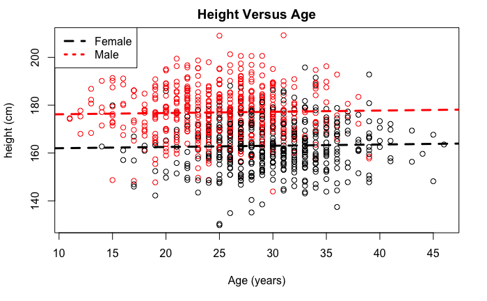

```r
title(main = "Height Versus Age")
```

### Question 6

- H0: age = 0
- HA: age != 0
- T-stat: 0.805
- P-value: 0.421
- Conclusion: Since the p-value is greater than the alpha of 0.05, we fail to reject the null hypothesis and suggest that age did not have an effect on height after taking gender into account.

## Questions 7, 8, 9 and 10

### Question 7

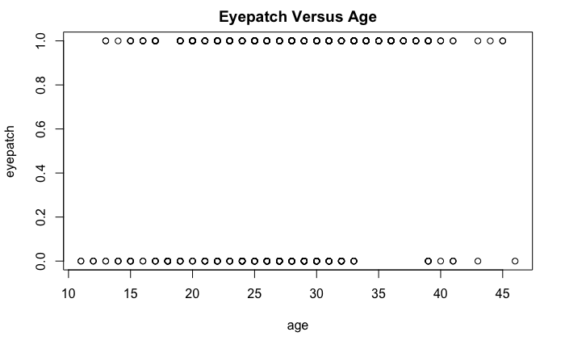

```r
# Basic plot to help explain question 7 answer
plot(eyepatch~age, data = pirates)
title(main = "Eyepatch Versus Age")
```

A linear model is not a good fit because eyepatch is a categorical variable with only two possible numeric values, 1 or 0. This is evident by the plot above. Additionally, linear models are meant to address numeric variables and not categorical.

### Question 8

The response variable is eyepatch and the explanatory variable is age.

### Question 9

```r
# Creating second linear model
fit2 <- glm(eyepatch ~ age, family = binomial, data = pirates)
summary(fit2)
```

```
Call:
glm(formula = eyepatch ~ age, family = binomial, data = pirates)

Deviance Residuals:
    Min       1Q   Median       3Q      Max
-2.1208  -1.3271   0.7345   0.8764   1.2363

Coefficients:
            Estimate Std. Error z value Pr(>|z|)
(Intercept) -1.03339    0.34380  -3.006  0.00265 **
age          0.06893    0.01268   5.437 5.41e-08 ***
---
Signif. codes:  0 ‘***’ 0.001 ‘**’ 0.01 ‘*’ 0.05 ‘.’ 0.1 ‘ ’ 1

(Dispersion parameter for binomial family taken to be 1)

    Null deviance: 1173.5  on 953  degrees of freedom
Residual deviance: 1142.6  on 952  degrees of freedom
AIC: 1146.6

Number of Fisher Scoring iterations: 4
```

### Question 10

Eyepatch(1 for yes, 0 for no) = -1.03339+ 0.06893(age(years))

## Questions 11, 12 and 13

### Question 11

I used the Wald statistic, which is essentially the z value. The z value is 5.437 and the respective p-value is 5.41e-08. This could calculated by the slope coefficient minus the null hypothesis all divided by the standard error.

### Question 12

```r
newage = data.frame(age = 40)
predict(fit2, newdata = newage, type = "response")
```

```
        1
0.8486158
```

### Question 13

```r
# Using confint.default function to get confidence interval
confint.default(fit2, level = .95)
```

```
                  2.5 %      97.5 %
(Intercept) -1.70722094 -0.35955321
age          0.04408271  0.09377592
```